# STATS 326/786

Week 7 Tutorial

# Problem 1

Consider the number of pigs slaughtered in Victoria, available in the `aus_livestock` data set. This is plotted below.

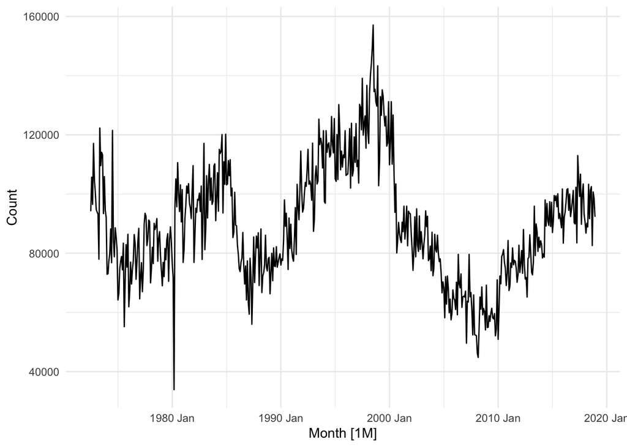

> Fit three different simple exponential smoothing (`ETS(A,N,N)`) models. One with $\alpha = 0.001$, one with $\alpha = 0.999$ and one with $\alpha$ that is automatically optimised. You can specify the value of $\alpha$ in the `trend` function.

> For the model where $\alpha$ was automatically optimised, extract and interpret the estimates of $l_0$ and $\alpha$.

> On three seperate plots overlay the fitted values on the original time series. Comment on what you observe.

> Using the `weight.plot` function provided below, plot the weights that the past 20 observations contribute to the exponenentially smoothed value at the current time point. Comment on what you observe.

```r
# Function to use
weight.plot = function(alpha, N = 20) {

  # alpha is the smoothing parameter for the level
  # N is the number of time points in the past to plot

  Weight = alpha    # First weight
  for (i in 2:N) {  # Other weights
    Weight[i] = Weight[i - 1] * (1 - alpha)
  }

  # Create tsibble
  data <- as_tsibble(data.frame(Time = (-(1:N)),
                      Weight = Weight),
           index = Time)

  # Plot
  ggplot(data = data, mapping = aes(x = Time, y = Weight)) +
    geom_segment(aes(x = Time, xend = Time,
                     y = 0, yend = Weight)) +
    theme_bw()

}
```

> For all three models, forecast 4 years into the future ($h = 48$) and plot these forecasts with their default prediction intervals. Comment on what you observe.

# Extra: Problem 2

Consider the Algerian exports time series in the `global_economy` data set. This is plotted below. An ETS(A,N,N) model is fitted to it and the optimal parameters are reported.

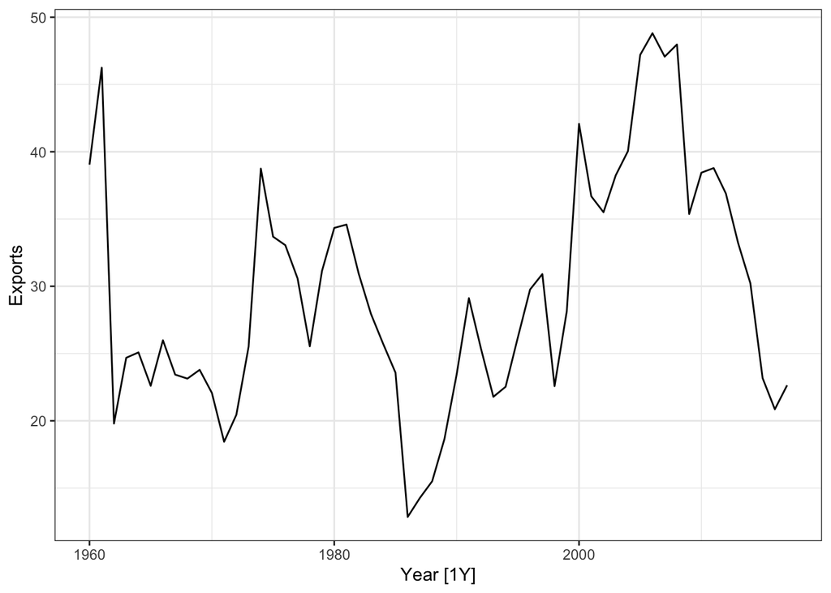

```r
algeria_economy <- global_economy %>%
  filter(Country == "Algeria")

algeria_economy %>%
  autoplot(Exports) +
  theme_bw()
```

```r
fit <- algeria_economy %>%
  model(ETS(Exports ~ error("A") + trend("N") + season("N")))
report(fit)  # Extract parameters
```

```
## Series: Exports
## Model: ETS(A,N,N)
##   Smoothing parameters:
##     alpha = 0.8399875
##
##   Initial states:
##    l[0]
##  39.539
##
##   sigma^2:  35.6301
##
##      AIC     AICc      BIC
## 446.7154 447.1599 452.8968
```

> Write your own function to implement simple exponential smoothing. The function should take arguments `y` (the time series), `alpha` (the smoothing parameter, $\alpha$) and `level` (the initial level, $l_0$). It should return the fitted values of the exponentially smoothed time series. Check to see that this function produces the same fitted values as `ETS()`.

> Modify your function from the previous exercise to return the sum of squared errors rather than the fitted values. Then use the `optim` function to find the optimal values of $\alpha$ and $l_0$. Do you get the same values as the `ETS()` function?